# Final Exam by Allex Nicole Belostrino

2023-12-09

Import Fuel Deliveries receipts and costs dataset. But first, remove columns with significant missing values. In this case it is mercury_content_ppm (Column Q), secondary_transportation_mode_code(Column R), and natural_gas_delivery_contract_type_code(Column T). Initially we have 21 columns, including the rowiD. This time, after removing columns, we will expect to have 18 columns total including rowID.

```r
Power <- read.csv("/Users/allexnicolebelostrino/Desktop/Final Exam Folder/Power.csv")
Power2 <- Power[ , -c(15,18,20)]
ncol(Power2)
```

```
## [1] 18
```

```r
nrow(Power2)
```

```
## [1] 663572
```

Let’s ensure our dataset has both the right attributes like numerical, character, and integer.

```r
str(Power2)
```

```
## 'data.frame':    663572 obs. of  18 variables:
##  $ rowid                           : int  1 2 3 4 5 6 7 8 9 10 ...
##  $ plant_id_eia                    : int  3 3 3 7 7 7 7 8 8 8 ...
##  $ report_date                     : chr  "1/1/08" "1/1/08" "1/1/08" "1/1/08" ...
##  $ contract_type_code              : chr  "C" "C" "C" "C" ...
##  $ contract_expiration_date        : chr  "4/1/08" "4/1/08" "" "12/1/15" ...
##  $ energy_source_code              : chr  "BIT" "BIT" "NG" "BIT" ...
##  $ fuel_type_code_pudl             : chr  "coal" "coal" "gas" "coal" ...
##  $ fuel_group_code                 : chr  "coal" "coal" "natural_gas" "coal" ...
##  $ mine_id_pudl                    : chr  "0" "0" "" "1" ...
##  $ supplier_name                   : chr  "interocean coal" "interocean coal" "bay gas pipeline" "alabama coal" ...
##  $ fuel_received_units             : int  259412 52241 2783619 25397 764 603 2341 8869 75442 206741 ...
##  $ fuel_mmbtu_per_unit             : num  23.1 22.8 1.04 24.61 24.45 ...
##  $ sulfur_content_pct              : num  0.49 0.48 0 1.69 0.84 1.54 0 2.16 1.24 1.9 ...
##  $ ash_content_pct                 : num  5.4 5.7 0 14.7 15.5 14.6 0 15.4 11.9 15.4 ...
##  $ fuel_cost_per_mmbtu             : num  2.13 2.12 8.63 2.78 3.38 ...
##  $ primary_transportation_mode_code: chr  "RV" "RV" "PL" "TR" ...
##  $ natural_gas_transport_code      : chr  "firm" "firm" "firm" "firm" ...
##  $ data_maturity                   : chr  "final" "final" "final" "final" ...
```

Randomly sample 2% of the dataset

```r
set.seed(3548)
total_rows <- nrow(Power2)
sample.size <- round(0.02 * total_rows)
sample.data <- Power2[sample(1:total_rows, size = sample.size, replace = FALSE), ]
```

Partition 70% of the sample data into training and the rest as test.

```r
#install.packages("caret")
#install.packages("ggplot2")
#install.packages("lattice")
library(caret)
#Create index for data partitioning
set.seed(3548)
index <- createDataPartition(y = 1:nrow(sample.data), p = 0.7, list = FALSE)

#Create training and testing
train <- sample.data[index, ]
test <- sample.data[-index, ]
```

Training set should be about 9,000 and test set should be about 3,000

```r
#Training set
length(train)
```

```
## [1] 18
```

```r
#Test Set
length(test)
```

```
## [1] 18
```

```r
nrow(train)
```

```
## [1] 9291
```

```r
nrow(test)
```

```
## [1] 3980
```

When checking from the data frame, training has 9,291 items while test has 3,980. Both sets have 18 columns.

Question 1: Which type of transportation is mostly used for delivering different fuels? (Coal, Gas, and Oil)

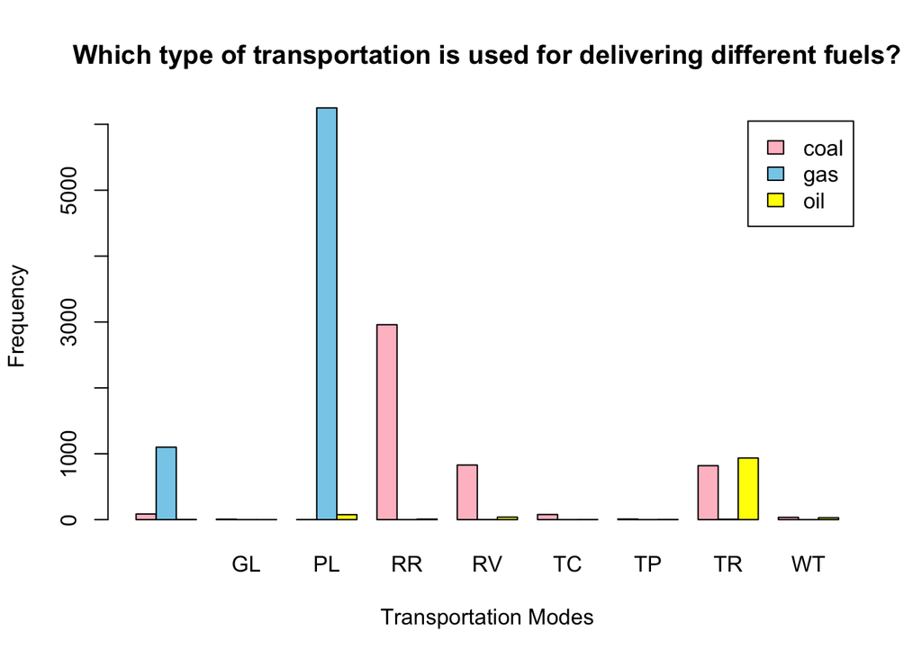

```r
transpo.data <- table(sample.data$fuel_type_code_pudl, sample.data$primary_transportation_mode_code)
barplot(transpo.data, beside = TRUE,
        legend.text = TRUE,
        col = c("pink", "skyblue", "yellow"),
        main = "Which type of transportation is used for delivering different fuels?",
        xlab = "Transportation Modes" , ylab = "Frequency")
```

In this bar plot, we compare the three types of fuels and their transportation differences.

Question 2: What information is revealed by clustering? Use any and all variables to describe and identify the clusters.

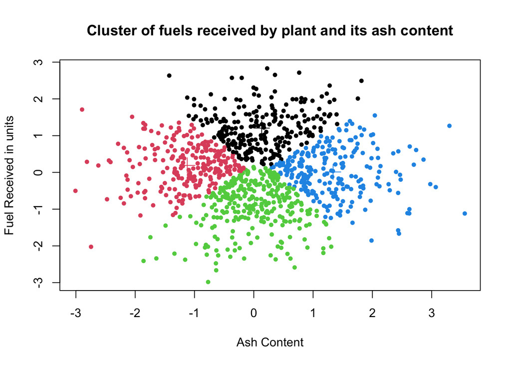

```r
#grab data
set.seed(3000)
sample.data <- data.frame(
  ash_content_pct = rnorm(1000),
  fuel_received_units = rnorm(1000)
)

#choose number of k
k <- 4

#do the clustering
kmeans.result <- kmeans(sample.data, centers = k)

cluster.assign <- kmeans.result$cluster

centroids <- kmeans.result$centers


#do the viz for kmeans
plot(
  sample.data$ash_content_pct,
 sample.data$fuel_received_units,
  col = cluster.assign,
  pch = 20,
  main = "Cluster of fuels received by plant and its ash content",
  xlab = "Ash Content",
  ylab = "Fuel Received in units"
)

points(centroids[ , 1], centroids[ ,2], col = 1:k, pch = 3, cex = 2)
```

for this cluster, I chose k = 4. However, by mere looking at the plot, I can tell that I should retain or lower the number of k since there are points that seem to be close to one another that should be a part of a cluster that is too far from them. If we chose a smaller number, we would have a more sensitive and accurate grouping.

Question 3: How should the value for the number of clusters be chosen?

```r
#Elbow method
#install.packages("factoextra")
library(factoextra)
```

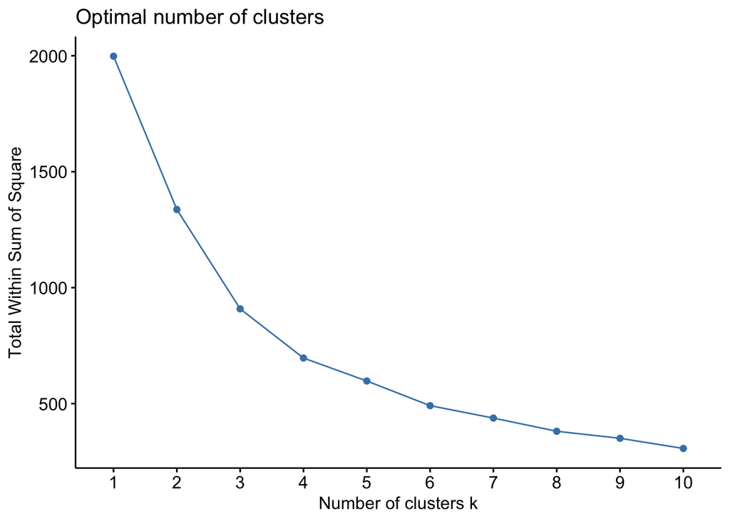

```r
sample.data <- scale(sample.data)
fviz_nbclust(sample.data, kmeans, method = "wss")
```

For choosing the optimal number of k, it is evident that in the elbow method there is a bend at k = 3

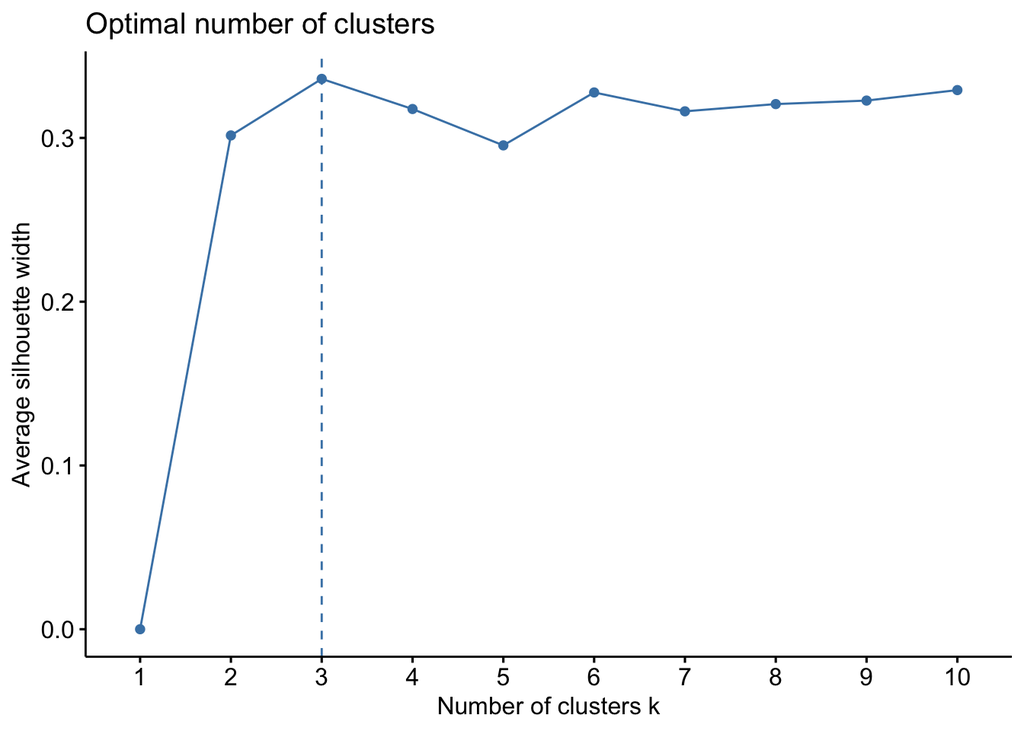

```r
#Silhouette method
fviz_nbclust(sample.data, kmeans, method = "silhouette")
```

We will then re-do the clustering using k=3

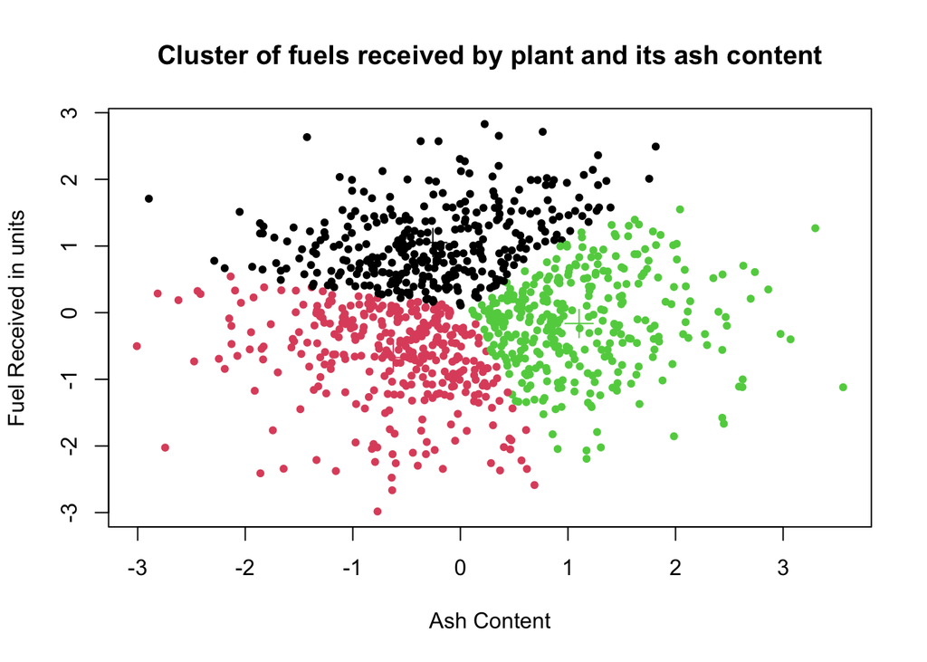

```r
set.seed(3000)
sample.data <- data.frame(
  ash_content_pct = rnorm(1000),
  fuel_received_units = rnorm(1000)
)

#choose number of k
k <- 3

#do the clustering
kmeans.result <- kmeans(sample.data, centers = k)

cluster.assign <- kmeans.result$cluster

centroids <- kmeans.result$centers


#do the viz for kmeans
plot(
  sample.data$ash_content_pct,
 sample.data$fuel_received_units,
  col = cluster.assign,
  pch = 20,
  main = "Cluster of fuels received by plant and its ash content",
  xlab = "Ash Content",
  ylab = "Fuel Received in units"
)

points(centroids[ , 1], centroids[ ,2], col = 1:k, pch = 3, cex = 2)
```